# STAT508_DAA4

Ada Lazuli

Tuesday, February 17, 2026

## Front Matter

```r
library(tidyverse)

NOVA <- read.csv("../sample_data/L04_NOVA.csv")
```

## Problem 1 - Preparing for Regression

### Preliminaries

```r
#Create a copy of NOVA named NOVA2
NOVA2 <- NOVA

#Find number of properties within each county
NOVA2 %>%
  group_by(CountySchool) %>%
  summarize(N = n())
```

```
## # A tibble: 4 × 2
##   CountySchool                             N
##   <chr>                                <int>
## 1 ARLINGTON COUNTY PUBLIC SCHOOLS        276
## 2 FAIRFAX COUNTY PUBLIC SCHOOLS          768
## 3 LOUDOUN COUNTY PUBLIC SCHOOLS            7
## 4 PRINCE WILLIAM COUNTY PUBLIC SCHOOLS     1
```

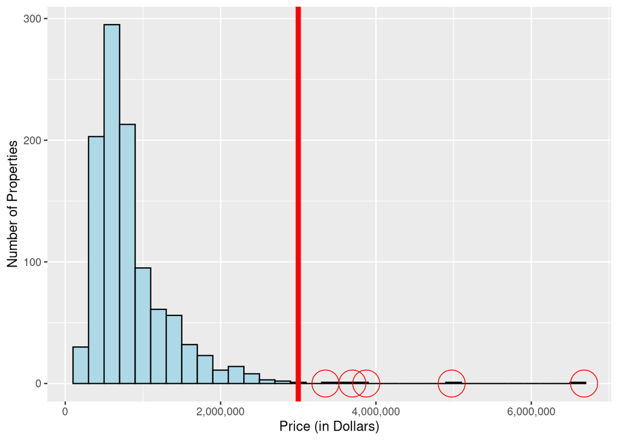

```r
#Create histogram of Prices and highlight outliers
ggplot(data = NOVA2, mapping = aes(x = Price)) +
  geom_histogram(binwidth = 200000, color = "black", fill = "lightblue") +
  labs(x = "Price (in Dollars)",
       y = "Number of Properties") +
  scale_x_continuous(labels = scales::comma) + #Removes scientific notation from axis labels
  geom_vline(xintercept = 3000000, color = "red", linewidth = 2) +
  geom_point(data = NOVA2[NOVA2$Price > 3000000,],aes(x = Price, y = 0),
             color = "red", shape = 1, size = 10)
```

### Part a. - Explore the outliers

```r
NOVA %>% filter(Price > 3000000)
```

```
##   Bedrooms Bathrooms LivingSQFT Age  DistToWH LotSize   ListingType Floors
## 1        5         7       7573   0  7996.266    0.37 Single Family      3
## 2        5         9       5000   1  5663.079    0.52 Single Family      3
## 3        7        12      15000   5 24674.127    7.97 Single Family      3
## 4        5         7      12000  10 24153.365    2.83 Single Family      3
## 5        5         8       8000   2 16714.793    3.39 Single Family      3
##                      CountySchool Garage   Price
## 1 ARLINGTON COUNTY PUBLIC SCHOOLS      2 3875000
## 2 ARLINGTON COUNTY PUBLIC SCHOOLS      3 3350000
## 3   FAIRFAX COUNTY PUBLIC SCHOOLS      4 6680000
## 4   FAIRFAX COUNTY PUBLIC SCHOOLS      4 3697000
## 5   FAIRFAX COUNTY PUBLIC SCHOOLS      3 4975000
```

It seems that the outliers differ based on the ratio of bathrooms to bedrooms, where the more expensive homes have a higher ratio. Exploring this further:

```r
NOVA %>% filter(Bedrooms > 0) %>%
  mutate(Ratio = Bathrooms/Bedrooms, Outlier = ifelse(Price > 3000000, "Yes", "No")) %>%
  group_by(Outlier) %>%
  summarise(Mean_Ratio = mean(Ratio),
            Mean_Bathrooms = mean(Bathrooms),
            Mean_Bedrooms = mean(Bedrooms))
```

```
## # A tibble: 2 × 4
##   Outlier Mean_Ratio Mean_Bathrooms Mean_Bedrooms
##   <chr>        <dbl>          <dbl>         <dbl>
## 1 No           0.992           3.76          3.86
## 2 Yes          1.58            8.6           5.4
```

The more expensive homes have meany more bathrooms on average.

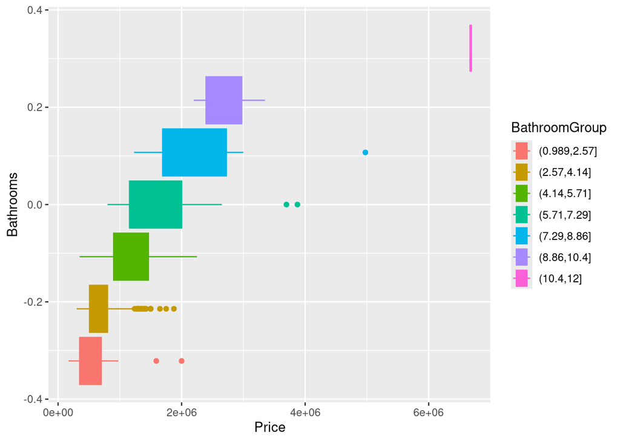

```r
temp <- NOVA %>%
  filter(Bedrooms > 0, Bathrooms >= 0) %>%
  mutate(BathroomGroup = cut(Bathrooms, breaks = 7),
         PriceGroup = cut(Price, breaks = 6))

ggplot(temp, aes(x = Price, color = BathroomGroup, fill = BathroomGroup)) +
  geom_boxplot() +
  labs(x = "Price", y = "Bathrooms")
```

It appears that the price increases as the number of bathrooms increases. The most expensive homes have significantly more bathrooms.

### Part b. - Remove outliers and counties with limited information

```r
NOVA2 <- NOVA %>%
  filter(Price < 3000000) %>%
  filter(CountySchool != "LOUDOUN COUNTY PUBLIC SCHOOLS") %>%
  filter(CountySchool != "PRINCE WILLIAM COUNTY PUBLIC SCHOOLS")
nrow(NOVA)
```

```
## [1] 1052
```

### Part c. - Transform the price

```r
NOVA2 <- NOVA2 %>% mutate(logPrice = log(Price))
```

### Part d. - Creating Indicator Variables

```r
NOVA2 <- NOVA2 %>% mutate(Single = ifelse(ListingType == "Single Family", 1, 0)) %>%
  mutate(Arlington = ifelse(CountySchool == "ARLINGTON COUNTY PUBLIC SCHOOLS", 1, 0))

# Sanity Check Lines
NOVA2 %>% summarise(MeanLogPrice = mean(logPrice))
```

```
##   MeanLogPrice
## 1     13.50511
```

```r
NOVA2 %>% summarise(MeanLogPrice = mean(Arlington))
```

```
##   MeanLogPrice
## 1    0.2637151
```

## Problem 2 - Linear Regression Inference

### Part a. - Build the model and provide a summary

```r
model1 <- lm(logPrice ~ Bedrooms + Bathrooms + LivingSQFT + Arlington + Floors, data = NOVA2)
summary(model1)
```

```
##
## Call:
## lm(formula = logPrice ~ Bedrooms + Bathrooms + LivingSQFT + Arlington +
##     Floors, data = NOVA2)
##
## Residuals:
##      Min       1Q   Median       3Q      Max
## -1.05177 -0.14804 -0.00636  0.13638  1.94312
##
## Coefficients:
##               Estimate Std. Error t value Pr(>|t|)
## (Intercept)  1.227e+01  4.428e-02 277.196  < 2e-16 ***
## Bedrooms     1.567e-01  9.801e-03  15.986  < 2e-16 ***
## Bathrooms    1.452e-01  8.911e-03  16.296  < 2e-16 ***
## LivingSQFT   1.194e-05  2.591e-06   4.608 4.58e-06 ***
## Arlington    4.378e-01  1.855e-02  23.600  < 2e-16 ***
## Floors      -2.492e-02  1.687e-02  -1.477     0.14
## ---
## Signif. codes:  0 '***' 0.001 '**' 0.01 '*' 0.05 '.' 0.1 ' ' 1
##
## Residual standard error: 0.2604 on 1033 degrees of freedom
## Multiple R-squared:  0.7333, Adjusted R-squared:  0.732
## F-statistic: 567.9 on 5 and 1033 DF,  p-value: < 2.2e-16
```

### Part b. - What is the relationship between bedrooms and logPrice after accounting for the other variables in the model?

After accounting for the other variables, for each unit increase in the number of bedrooms, the log price increases by 0.1567. This is evidenced by the Estimate for the Bedrooms from the model summary.

### Part c. - What proportion of the total variation in logPrice is explained by the model including the other variables?

Using the multiple $R^2$ value from the table, approximately 73.33% of the variation in logPrice is explained by the variables used in the model.

### Part d. - Should floors be added to the model for logPrice after accounting for the other variables in the model?

Using the model summary, the t-statistic and p-value are 1.477 and 0.14, respectively. These values suggest that the Floors variable should be removed from the model.

## Problem 3 - Predictive Performance of the Linear Regression Model

### Part a - Perform and 80/20 training/validation split using a seed of 92023

```r
set.seed(92023)
train_ind <- sample(x = 1:nrow(NOVA2), size = floor(0.8*nrow(NOVA2)), replace = FALSE)
set.seed(NULL)

train <- NOVA2[train_ind,]
validation <- NOVA2[-train_ind,]
```

### Part b. - Complete the table (Include code and RMSE calculations for ALL models)

```r
model1 <- lm(logPrice ~ Bedrooms + Bathrooms + LivingSQFT + Arlington, data = train)
s1 <- summary(model1)
model1_rsq <- s1$r.squared
model1_adjrsq <- s1$adj.r.squared

model1_MSEtrain <- mean((model1$residuals)^2)
model1_RMSEtrain <- sqrt(model1_MSEtrain)

yhatVal1 <- predict(model1, newdata = validation)
model1_MSEval <- mean((validation$logPrice - yhatVal1)^2)
model1_RMSEval <- sqrt(model1_MSEval)


model2 <- lm(logPrice ~ Bedrooms + Bathrooms + LivingSQFT + Arlington + Floors, data = train)
s2 <- summary(model2)
model2_rsq <- s2$r.squared
model2_adjrsq <- s2$adj.r.squared

model2_MSEtrain <- mean((model2$residuals)^2)
model2_RMSEtrain <- sqrt(model2_MSEtrain)

yhatVal2 <- predict(model2, newdata = validation)
model2_MSEval <- mean((validation$logPrice - yhatVal2)^2)
model2_RMSEval <- sqrt(model2_MSEval)

model3 <- lm(logPrice ~ Bedrooms + Bathrooms + LivingSQFT + Arlington + Floors + Garage + DistToWH, data = train)
s3 <- summary(model3)
model3_rsq <- s3$r.squared
model3_adjrsq <- s3$adj.r.squared

model3_MSEtrain <- mean((model3$residuals)^2)
model3_RMSEtrain <- sqrt(model3_MSEtrain)

yhatVal3 <- predict(model3, newdata = validation)
model3_MSEval <- mean((validation$logPrice - yhatVal3)^2)
model3_RMSEval <- sqrt(model3_MSEval)
```

| Model | Features Included | $R^2$ | $R^2_{adj}$ | Train RMSE | Validation RMSE |
| --- | --- | --- | --- | --- | --- |
| 1 | Bedrooms, Bathrooms, LivingSQFT, Arlington | 0.7322034 | 0.7309066 | 0.2608849 | 0.2588512 |
| 2 | Bedrooms, Bathrooms, LivingSQFT, Arlington, Floors | 0.7335227 | 0.7319077 | 0.2602415 | 0.2603401 |
| 3 | Bedrooms, Bathrooms, LivingSQFT, Arlington, Floors, Garage, DistToWH | 0.7939829 | 0.7922306 | 0.2288221 | 0.2037637 |

### Part c. - Which model would you choose based on this data? Explain.

Based on the results, model3 seems to be the most appropriate based on the lowest Validation RMSE. The validation RMSE provides insight into how the model will perform against new data. Additionally, model3 is able to explain more of the variation in the price compared to models 1 and 2.

### Part d. - Calculate validation RMSE in dollars for Model 3 from Part b.

```r
yhatVal3 <- predict(model3, newdata = validation)
yhatVal3_exp <- exp(yhatVal3)
model3_MSEval <- mean((validation$Price - yhatVal3_exp)^2)
model3_RMSEval_dollars <- sqrt(model3_MSEval)
model3_RMSEval_dollars
```

```
## [1] 175432
```

The Root Mean Squared Error for model 3 is approximately 175000$.

## Problem 4 - Some Considerations

### Part a. - What is happening with seed 92025

```r
set.seed(92025)
train_ind <- sample(x = 1:nrow(NOVA2), size = floor(0.8*nrow(NOVA2)), replace = FALSE)
set.seed(NULL)

train <- NOVA2[train_ind,]
validation <- NOVA2[-train_ind,]

model3 <- lm(logPrice ~ Bedrooms + Bathrooms + LivingSQFT + Arlington + Floors + Garage + DistToWH, data = train)

yhatVal3 <- predict(model3, newdata = validation)
yhatVal3_exp <- exp(yhatVal3)

resids <- abs(validation$Price - yhatVal3_exp)
largest_residual <- max(resids)
largest_residual_idx <- which.max(resids)
```

The largest residual using the validation set approach with seed 92025 is 9.8615812^{10} at index 206 in the validation dataset.

```r
validation[largest_residual_idx,]
```

```
##      Bedrooms Bathrooms LivingSQFT Age DistToWH LotSize   ListingType Floors
## 1031        5         4      99999  42 19863.99    0.36 Single Family      3
##                       CountySchool Garage  Price logPrice Single Arlington
## 1031 FAIRFAX COUNTY PUBLIC SCHOOLS      0 895000 13.70458      1         0
```

## Problem 5 - Some Considerations 2

### Part a. - What is causing the error message?

```r
#Perform Training/Validation Split
validation_inds <- c(411, 434, 443, 445, 446, 447, 448, 898)

trainTemp <- NOVA[-validation_inds, ]
validationTemp <- NOVA[validation_inds, ]

#Build Model
modelTemp <- lm(Price ~ LotSize + CountySchool, data = trainTemp)

#Estimate RMSE on Validation Set
yhatTemp <- predict(modelTemp, newdata = validationTemp)
```

```
## Error in `model.frame.default()`:
## ! factor CountySchool has new levels LOUDOUN COUNTY PUBLIC SCHOOLS, PRINCE WILLIAM COUNTY PUBLIC SCHOOLS
```

```r
table(validationTemp$CountySchool)
```

```
##
##        LOUDOUN COUNTY PUBLIC SCHOOLS PRINCE WILLIAM COUNTY PUBLIC SCHOOLS
##                                    7                                    1
```

```r
table(train$CountySchool)
```

```
##
## ARLINGTON COUNTY PUBLIC SCHOOLS   FAIRFAX COUNTY PUBLIC SCHOOLS
##                             202                             629
```

The problem with this final validation set is that it only has County School observations for “LOUDOUN COUNTY PUBLIC SCHOOLS” and “PRINCE WILLIAM COUNTY PUBLIC SCHOOLS” while the training set only has observations for “ARLINGTON COUNTY PUBLIC SCHOOLS” and “FAIRFAX COUNTY PUBLIC SCHOOLS”. While determining the predictions with the validation set, R raises an exception due to the “new” factor levels.

An approach that would make this split work would be to encode the `CountySchool` feature differently. For example:

```r
NOVA <- NOVA %>% mutate(
  LOUDOUN = ifelse(CountySchool == "LOUDOUN COUNTY PUBLIC SCHOOLS", 1, 0),
  WILLIAM = ifelse(CountySchool == "PRINCE WILLIAM COUNTY PUBLIC SCHOOLS", 1, 0),
  ARLINGTON = ifelse(CountySchool == "ARLINGTON COUNTY PUBLIC SCHOOLS", 1, 0),
  FAIRFAX = ifelse(CountySchool == "FAIRFAX COUNTY PUBLIC SCHOOLS", 1, 0),
)

validation_inds <- c(411, 434, 443, 445, 446, 447, 448, 898)

trainTemp <- NOVA[-validation_inds, ]
validationTemp <- NOVA[validation_inds, ]

#Build Model
modelTemp <- lm(Price ~ LotSize + LOUDOUN + WILLIAM + ARLINGTON + FAIRFAX, data = trainTemp)

#Estimate RMSE on Validation Set
yhatTemp <- predict(modelTemp, newdata = validationTemp)
modeltemp_MSEval <- mean((validationTemp$Price - yhatTemp)^2)
modeltemp_RMSEval <- sqrt(modeltemp_MSEval)
modeltemp_RMSEval
```

```
## [1] 186039.5
```

The last model has a valdation RMSE of approximately 186000$